# Getting Started with grip

Installed figures use static projections. To enable 3D rotation and layout selection, render with `options(grip.vignette.interactive = TRUE)` and **ivue** and **rgl** installed.

Start with a graph whose structure you want to explore. This example uses **dwt_307**, a 307-vertex structural graph from the [SuiteSparse Matrix Collection](https://sparse.tamu.edu/HB/dwt_307), supplied with grip. Its edges describe connectivity; the drawing has no known spatial reference that the layout must recover.

## Load a graph and draw it

```r
g <- suitesparse.graph('dwt_307')
fit <- metric.mds(edges=g$edges, n=g$n, dim=3, backend="sgd",
                  seed=1, diagnostics=FALSE)
coords <- fit$coords
```

Each row of `g$edges` contains two vertex indices, numbered from 1 to `g$n`. Each row of `coords` gives the position of the corresponding vertex. Metric MDS with SGD fits Euclidean separations to graph shortest-path distances. Here all edges have unit length, so targets are hop distances. Inspect the fit diagnostics and termination status; a returned layout does not imply convergence.

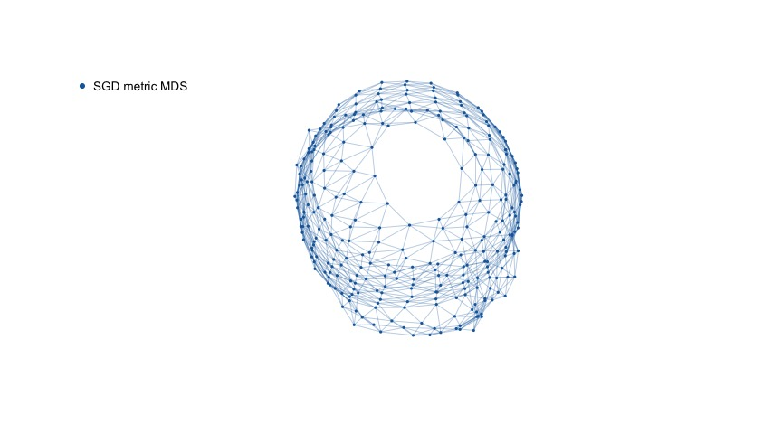

dwt_307: 307 vertices. SGD metric MDS with seed 1.

Rotate the graph to inspect its structure. All vertices and edges are shown. For a quick view in an interactive R session, use:

```r
ivue::plot3D.plain(coords, layers=list(ivue::layer3D.edges(g$edges)), controls = FALSE)
```

## Assess the drawing

```r
quality <- score.layout(coords, edges=g$edges, n=g$n,
                        edge.crossings='never')
knitr::kable(quality[,c('sampled.stress','edge.length.cv',
                       'sampled.nonedge.sep.ratio')],digits=3)
```

| sampled.stress | edge.length.cv | sampled.nonedge.sep.ratio |
| --- | --- | --- |
| 0.11 | 0.225 | 1.072 |

Sampled stress compares drawn distances with graph shortest paths after fitting one common scale; smaller values mean closer agreement. Edge-length variation shows how evenly the unit edges are drawn. Nonedge separation describes how far apart unconnected vertices lie relative to edges. These measures describe different aspects of a drawing; no single number captures readability.

## Metric MDS controls

`metric.mds()` directly fits Euclidean distances to graph shortest-path distances. Its default SGD backend adjusts pairs of vertices in shuffled order, following [Zheng, Pawar and Goodman (2018)](https://doi.org/10.1109/TVCG.2018.2859997) with the learning-rate schedule of [Hangan, Kobourov and Miller (2026)](https://arxiv.org/abs/2605.00641).

```r
mds <- suppressWarnings(metric.mds(
  edges=g$edges, n=g$n, dim=3, init='random',
  max.iter=80, seed=1, diagnostics=FALSE))
mds$metadata$termination
```

```
#> [1] "iteration_limit"
```

The 80-pass allowance is a short illustrative setting. Schedule completion reports `iteration_limit`; it does not establish convergence. The figure compares this random-start, 80-pass fit with the default-initialization MDS fit above, which uses the default 1,000-pass budget. The display allows rotation, reflection, and translation and matches overall size with one uniform multiplier per layout. This does not change the fitted coordinates or scores. Because both initialization and budget differ, this is an illustration, not an isolated test of either choice.

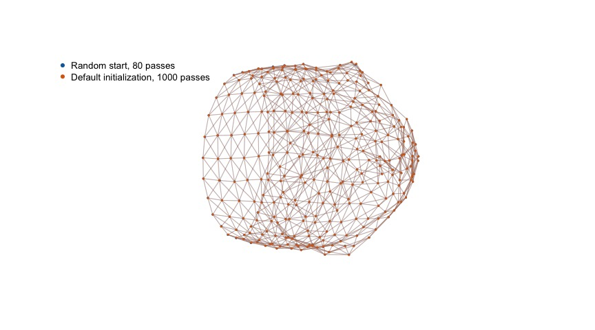

dwt_307: two SGD metric-MDS runs with different initialization and pass budgets. Aligned at a common overall size for display. Seed 1. Display multipliers: Random start, 80 passes 1; Default initialization, 1000 passes 1 . Scores use original coordinates.

Select a layout below the figure, or show both. For optimizer and weighting choices, continue to Metric MDS. Larger graphs may benefit from sparse metric MDS.

## Choose the next step

| Your next question | Vignette |
| --- | --- |
| What functions are available? | Finding your way around grip |
| What other graphs can I draw? | Graph gallery |
| Which settings or seeds should I use? | Choosing and evaluating a layout |
| How do normalization and distance affect a 3D fit? | [What does a 3D embedding preserve?](https://pgajer.github.io/grip/articles/embedding-fidelity.html) (website article) |
| Should I refit a selection or keep its population coordinates? | [Local embeddings versus subsets of a global embedding](https://pgajer.github.io/grip/articles/local-global-embeddings.html) (website article) |
| How do I compare views with consistent colors, scales and cameras? | [Comparing scientific views in ivue](https://pgajer.github.io/ivue/doc/ivue-introduction.html#comparing-scientific-views) |
| My edges represent distances | Layouts with meaningful edge lengths |
| How did the drawing develop? | Tracing and diagnosing layouts |
| How do I explore saved results? | Interactive exploration with gripui |

Edge values that describe connection strength are not automatically suitable as distances. In particular, the bundled SuiteSparse examples use unit traversal lengths and retain their original matrix values separately. The graph gallery provides source attribution and conversion details.